# Analyzing hurricane tracks - Part 2/3

This is the second part to a three part set of notebooks that process and analyze historic hurricane tracks. In the previous notebook we saw

1. downloading historic hurricane datasets using Python
2. cleaning and merging hurricane observations using DASK
3. aggregating point observations into hurricane tracks using ArcGIS GeoAnalytics server

In this notebook you will analyze the aggregated tracks to answer important questions about prevalance of hurricanes, their seasonality, their density, places where they make landfall and investigate the communities that are most affected.

# **Table of Contents**

Import the libraries necessary for this notebook.

```python
# import ArcGIS Libraries
from arcgis.gis import GIS
from arcgis.geometry import filters
from arcgis.geocoding import geocode
from arcgis.features.manage_data import overlay_layers
from arcgis.geoenrichment import enrich

# import Pandas for data exploration
import pandas as pd
import numpy as np
from scipy import stats

# import plotting libraries
import matplotlib.pyplot as plt
import seaborn as sns
%matplotlib inline

# import display tools
from pprint import pprint
from IPython.display import display

# import system libs
from sys import getsizeof
```

```python
gis = GIS('home')
```

```python
import warnings
warnings.filterwarnings('ignore')
```

## Access aggregated hurricane data

Below, we access the tracks aggregated using GeoAnalytics in the previous notebook.

```python
hurricane_tracks_item = gis.content.search('title:hurricane_tracks_aggregated_ga')[0]
hurricane_fl = hurricane_tracks_item.layers[0]
```

The **GeoAnalytics** step calculated summary statistics of all numeric fields. However only a few of the columns are of interest to us.

```python
pprint([f['name'] for f in hurricane_fl.properties.fields], compact=True, width=80)
```

```
['objectid', 'serial_num', 'count', 'count_col_1', 'sum_col_1', 'min_col_1',
 'max_col_1', 'mean_col_1', 'range_col_1', 'sd_col_1', 'var_col_1',
 'count_season', 'sum_season', 'min_season', 'max_season', 'mean_season',
 'range_season', 'sd_season', 'var_season', 'count_num', 'sum_num', 'min_num',
 'max_num', 'mean_num', 'range_num', 'sd_num', 'var_num', 'count_basin',
 'any_basin', 'count_sub_basin', 'any_sub_basin', 'count_name', 'any_name',
 'count_iso_time', 'any_iso_time', 'count_nature', 'any_nature', 'count_center',
 'any_center', 'count_track_type', 'any_track_type', 'count_current_basin',
 'any_current_basin', 'count_latitude_merged', 'sum_latitude_merged',
 'min_latitude_merged', 'max_latitude_merged', 'mean_latitude_merged',
 'range_latitude_merged', 'sd_latitude_merged', 'var_latitude_merged',
 'count_longitude_merged', 'sum_longitude_merged', 'min_longitude_merged',
 'max_longitude_merged', 'mean_longitude_merged', 'range_longitude_merged',
 'sd_longitude_merged', 'var_longitude_merged', 'count_wind_merged',
 'sum_wind_merged', 'min_wind_merged', 'max_wind_merged', 'mean_wind_merged',
 'range_wind_merged', 'sd_wind_merged', 'var_wind_merged',
 'count_pressure_merged', 'sum_pressure_merged', 'min_pressure_merged',
 'max_pressure_merged', 'mean_pressure_merged', 'range_pressure_merged',
 'sd_pressure_merged', 'var_pressure_merged', 'count_grade_merged',
 'sum_grade_merged', 'min_grade_merged', 'max_grade_merged',
 'mean_grade_merged', 'range_grade_merged', 'sd_grade_merged',
 'var_grade_merged', 'count_eye_dia_merged', 'sum_eye_dia_merged',
 'min_eye_dia_merged', 'max_eye_dia_merged', 'mean_eye_dia_merged',
 'range_eye_dia_merged', 'sd_eye_dia_merged', 'var_eye_dia_merged',
 'track_duration', 'end_datetime', 'start_datetime']
```

Below we select the following fields for the rest of this analysis.

```python
fields_to_query = ['objectid', 'count', 'min_season', 'any_basin', 'any_sub_basin',
                   'any_name', 'mean_latitude_merged', 'mean_longitude_merged',
                   'max_wind_merged', 'range_wind_merged', 'min_pressure_merged',
                   'range_pressure_merged', 'max_eye_dia_merged', 'track_duration',
                   'end_datetime', 'start_datetime']
```

### Query hurricane tracks into a Spatially enabled `DataFrame`

```python
%%time
all_hurricanes_df = hurricane_fl.query(out_fields=','.join(fields_to_query), as_df=True)
```

```
CPU times: user 1.12 s, sys: 318 ms, total: 1.43 s
Wall time: 4.5 s
```

```python
all_hurricanes_df.shape
```

```
(12362, 17)
```

There are **`12,362`** hurricanes identified by GeoAnalytics aggregate tracks tool. To get an idea about this aggregated dataset, call the `head()` method.

```python
all_hurricanes_df.head()
```

|  | SHAPE | any_basin | any_name | any_sub_basin | count | end_datetime | max_eye_dia_merged | max_wind_merged | mean_latitude_merged | mean_longitude_merged | min_pressure_merged | min_season | objectid | range_pressure_merged | range_wind_merged | start_datetime | track_duration |
| --- | --- | --- | --- | --- | --- | --- | --- | --- | --- | --- | --- | --- | --- | --- | --- | --- | --- |
| 0 | {"paths": [[[59.60000000000002, -17.6000000000... | SI | NOT NAMED | MM | 7.0 | 1854-02-10 18:00:00 | NaN | NaN | -19.318571 | 60.639286 | NaN | 1854.0 | 1 | NaN | NaN | 1854-02-08 06:00:00 | 1.296000e+08 |
| 1 | {"paths": [[[-23.5, 12.5], [-24.19999999999999... | NA | NOT NAMED | NA | 9.0 | 1859-08-26 12:00:00 | NaN | 45.0 | 14.000000 | -26.222222 | NaN | 1859.0 | 2 | NaN | 10.0 | 1859-08-24 12:00:00 | 1.728000e+08 |
| 2 | {"paths": [[[-23.19999999999999, 12.1000000000... | NA | UNNAMED | NA | 50.0 | 1853-09-12 18:00:00 | NaN | 130.0 | 26.982000 | -51.776000 | 924.0 | 1853.0 | 3 | 53.0 | 90.0 | 1853-08-30 00:00:00 | 1.058400e+09 |
| 3 | {"paths": [[[59.80000000000001, -15.5], [59.49... | SI | XXXX856017 | MM | 13.0 | 1856-04-05 18:00:00 | NaN | NaN | -20.185385 | 59.573077 | NaN | 1856.0 | 4 | NaN | NaN | 1856-04-02 18:00:00 | 2.592000e+08 |
| 4 | {"paths": [[[99.60000000000002, -11.5], [98.30... | SI | NOT NAMED | WA | 13.0 | 1861-03-15 18:00:00 | NaN | NaN | -12.940769 | 94.183846 | NaN | 1861.0 | 5 | NaN | NaN | 1861-03-12 18:00:00 | 2.592000e+08 |

To better analyze this data set, the date columns need to be changed to a format that Pandas understands better. This is accomplished by calling `to_datetime()` method and passing the appropriate time columns.

```python
all_hurricanes_df['start_datetime'] = pd.to_datetime(all_hurricanes_df['start_datetime'])
all_hurricanes_df['end_datetime'] = pd.to_datetime(all_hurricanes_df['end_datetime'])
all_hurricanes_df.index = all_hurricanes_df['start_datetime']
all_hurricanes_df.head()
```

| start_datetime | SHAPE | any_basin | any_name | any_sub_basin | count | end_datetime | max_eye_dia_merged | max_wind_merged | mean_latitude_merged | mean_longitude_merged | min_pressure_merged | min_season | objectid | range_pressure_merged | range_wind_merged | start_datetime | track_duration |
| --- | --- | --- | --- | --- | --- | --- | --- | --- | --- | --- | --- | --- | --- | --- | --- | --- | --- |
| 1854-02-08 06:00:00 | {"paths": [[[59.60000000000002, -17.6000000000... | SI | NOT NAMED | MM | 7.0 | 1854-02-10 18:00:00 | NaN | NaN | -19.318571 | 60.639286 | NaN | 1854.0 | 1 | NaN | NaN | 1854-02-08 06:00:00 | 1.296000e+08 |
| 1859-08-24 12:00:00 | {"paths": [[[-23.5, 12.5], [-24.19999999999999... | NA | NOT NAMED | NA | 9.0 | 1859-08-26 12:00:00 | NaN | 45.0 | 14.000000 | -26.222222 | NaN | 1859.0 | 2 | NaN | 10.0 | 1859-08-24 12:00:00 | 1.728000e+08 |
| 1853-08-30 00:00:00 | {"paths": [[[-23.19999999999999, 12.1000000000... | NA | UNNAMED | NA | 50.0 | 1853-09-12 18:00:00 | NaN | 130.0 | 26.982000 | -51.776000 | 924.0 | 1853.0 | 3 | 53.0 | 90.0 | 1853-08-30 00:00:00 | 1.058400e+09 |
| 1856-04-02 18:00:00 | {"paths": [[[59.80000000000001, -15.5], [59.49... | SI | XXXX856017 | MM | 13.0 | 1856-04-05 18:00:00 | NaN | NaN | -20.185385 | 59.573077 | NaN | 1856.0 | 4 | NaN | NaN | 1856-04-02 18:00:00 | 2.592000e+08 |
| 1861-03-12 18:00:00 | {"paths": [[[99.60000000000002, -11.5], [98.30... | SI | NOT NAMED | WA | 13.0 | 1861-03-15 18:00:00 | NaN | NaN | -12.940769 | 94.183846 | NaN | 1861.0 | 5 | NaN | NaN | 1861-03-12 18:00:00 | 2.592000e+08 |

The track duration and length columns need to be projected to units (days, hours, miles) that are meaningful for analysis.

```python
all_hurricanes_df['track_duration_hrs'] = all_hurricanes_df['track_duration'] / 3600000
all_hurricanes_df['track_duration_days'] = all_hurricanes_df['track_duration'] / (3600000*24)
```

## Exploratory data analysis

In this section we perform exploratory analysis of the dataset and answer some interesting questions.

[figure not shown]

```python
map1 = gis.map('USA')
map1
```

```python
all_hurricanes_df.sample(n=500, random_state=2).spatial.plot(map1,
                                                             renderer_type='u',
                                                             col='any_basin',
                                                            cmap='prism')
```

```
True
```

The map above draws a set of `500` hurricanes chosen at random. You can visualize the Spatially Enabled DataFrame object with different types of renderers. In the example above a unique value renderer is applied on the **basin** column. You can switch the map to 3D mode and view the same on a globe.

[figure not shown]

```python
map2 = gis.map()
map2.mode= '3D'
map2
```

```python
all_hurricanes_df.sample(n=500, random_state=2).spatial.plot(map2,
                                                             renderer_type='u',
                                                             col='any_basin',
                                                            cmap='prism')
```

### Does the number of hurricanes increase with time?

To understand if number of hurricanes have increased over time, we will plot a histogram of the `MIN_Season` column.

```
Text(0.5,1,'Number of hurricanes recorded over time')
```

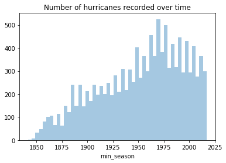

```python
ax = sns.distplot(all_hurricanes_df['min_season'], kde=False, bins=50)
ax.set_title('Number of hurricanes recorded over time')
```

The number of hurricanes recorded increases steadily until `1970`. This could be due to advances in geospatial technologies allowing scientists to better monitor hurricanes. However, after `1970` we notice a reduction in the number of hurricanes. This is in line with what [scientists observe and predict](https://www.nytimes.com/2018/10/10/climate/hurricane-michael-climate-change.html).

### How many hurricanes occuer per basin and sub basin?

Climate scientists have organized global hurricanes into `7` basins and a number of sub basins. The snippet below plots groups the data by basin and sub basin, counts the occurrences and plots the frequency in bar charts.

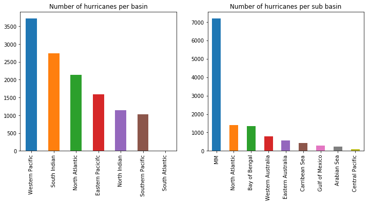

```python
fig1, ax1 = plt.subplots(1,2, figsize=(12,5))

basin_ax = all_hurricanes_df['any_basin'].value_counts().plot(kind='bar', ax=ax1[0])
basin_ax.set_title('Number of hurricanes per basin')
basin_ax.set_xticklabels(['Western Pacific', 'South Indian', 'North Atlantic',
                          'Eastern Pacicifc', 'North Indian','Southern Pacific',
                          'South Atlantic'])

sub_basin_ax = all_hurricanes_df['any_sub_basin'].value_counts().plot(kind='bar', ax=ax1[1])
sub_basin_ax.set_title('Number of hurricanes per sub basin')
sub_basin_ax.set_xticklabels(['MM','North Atlantic','Bay of Bengal','Western Australia',
                             'Eastern Australia', 'Carribean Sea', 'Gulf of Mexico',
                             'Arabian Sea', 'Central Pacific'])
sub_basin_ax.tick_params()
```

Thus, most hurricanes occur in **Wester Pacific** basin. This is the region that is east of China, Phillipines and rest of South East Asia. This is followed by **South Indian** which spans from west of Australia to east of Southern Africa. **North Atlantic** basin which is the source of hurricanes in the continental United States ranks as the third busiest hurricane basin.

### Are certain hurricane names more popular?

Pandas provides a handy API called `value_counts()` to count unique occurrences. We use that below to count the number of times each hurricane name has been used. We then print the top `25` most frequently used names.

```python
# Get the number of occurrences of top 25 hurricane names
all_hurricanes_df['any_name'].value_counts()[:25]
```

```
NOT NAMED          4099
UNNAMED            1408
06B                  31
05B                  30
04B                  30
09B                  30
07B                  29
08B                  29
10B                  29
03B                  28
01B                  27
12B                  26
11B                  23
13B                  23
02B                  22
14B                  17
SUBTROP:UNNAMED      16
IRMA                 15
FLORENCE             15
02A                  14
JUNE                 13
ALICE                13
OLGA                 13
SUSAN                13
FREDA                13
Name: any_name, dtype: int64
```

Names like `FLORENCE`, `IRMA`, `OLGA`.. appear to be more popular. Interestingly all are of female gender. We can take this further to explore at what time periods have the name `FLORENCE` been used?

```python
all_hurricanes_df[all_hurricanes_df['any_name']=='FLORENCE'].index
```

```
DatetimeIndex(['1953-09-23 12:00:00', '1954-09-10 12:00:00',
               '1963-07-14 12:00:00', '1967-01-03 06:00:00',
               '1964-09-05 18:00:00', '1965-09-08 00:00:00',
               '1973-07-25 00:00:00', '1960-09-17 06:00:00',
               '1994-11-02 00:00:00', '1969-09-02 00:00:00',
               '2012-08-03 06:00:00', '1977-09-20 12:00:00',
               '2000-09-10 18:00:00', '1988-09-07 06:00:00',
               '2006-09-03 18:00:00'],
              dtype='datetime64[ns]', name='start_datetime', freq=None)
```

The name `FLORENCE` had been used consistently in since the 1950s, reaching a peak in popularity during the 60s.

### Is there a seasonality in the occurrence of hurricanes?

Hurricanes happen when water temperatures (`Sea Surface Temperature` SST) are warm. Solar incidence is one of the key factors affecting SST and this typically happens during summer months. However, summer happens during different months in northern and southern hemispheres. To visualize this seasonality, we need to group our data by month as well as basin. Thus the snippet below creates a multilevel index grouper in Pandas

```python
# Create a grouper object
grouper = all_hurricanes_df.start_datetime.dt.month_name()

# use grouper along with basin name to create a multilevel groupby object
hurr_by_basin = all_hurricanes_df.groupby([grouper,'any_basin'], as_index=True)
hurr_by_basin_month = hurr_by_basin.count()[['count', 'min_pressure_merged']]
hurr_by_basin_month.head()
```

| start_datetime | any_basin | count | min_pressure_merged |
| --- | --- | --- | --- |
| April | NA | 5 | 2 |
|  | NI | 41 | 5 |
|  | SI | 242 | 85 |
|  | SP | 97 | 74 |
|  | WP | 83 | 56 |

Now we turn the index into columns for further processing.

```python
# turn index into columns
hurr_by_basin_month.reset_index(inplace=True)
hurr_by_basin_month.drop('min_pressure_merged', axis=1, inplace=True)
hurr_by_basin_month.columns = ['month', 'basin', 'count']
hurr_by_basin_month.head()
```

|  | month | basin | count |
| --- | --- | --- | --- |
| 0 | April | NA | 5 |
| 1 | April | NI | 41 |
| 2 | April | SI | 242 |
| 3 | April | SP | 97 |
| 4 | April | WP | 83 |

We add the month column back, but this time we will help Pandas understand how to sort months other than by alphabetical order.

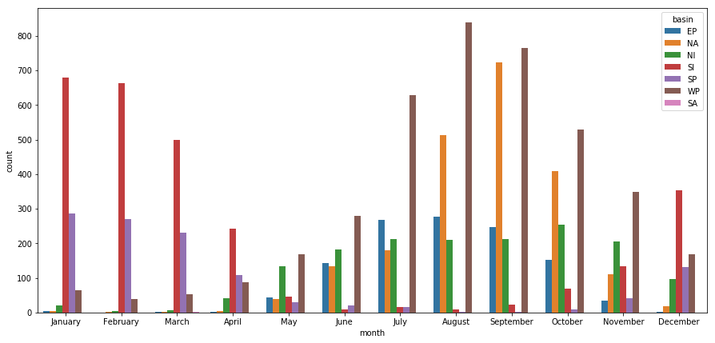

```python
fig, ax = plt.subplots(1,1, figsize=(15,7))
month_order = ['January','February', 'March','April','May','June',
              'July','August','September','October','November','December']

sns.barplot(x='month', y='count', hue='basin', data=hurr_by_basin_month, ax=ax,
            order=month_order)
```

The bars in **red** represent the number of hurricanes in **Sounth Indian** ocean which spans from west of Australia to east of southern Africa while the **brown** bars are for **Western Pacific** which spans east of China and **orange** bars for **North Atlantic**. The sinusoidal nature of these bars show the charateristic offset in summer between northern and southern hemispheres. The **green** bars represent **North Indian** hurricanes which is dominated by monsoon effect and is seen to be prevalant for most part of the year.

### What percent of hurricanes make landfall?

While exploring the hurricane data on maps, we noticed their geographic distribution and that they travel long distances over the oceans. Thus, do all hurricanes eventually make landfall? If not, what percent of them do? This is an important question to answer as the threat to human life decreases dramatically when a hurricane does not make a landfall.

We will answer this question by performing **overlay analysis**. For this, we need to intersect the hurricane tracks with world boundary dataset. We will make an anonymous connection to ArcGIS Online to look for a layer published by Esri in living atlas.

```python
agol = GIS(set_active=False)
```

```python
world_boundaries_item = agol.content.get('57c1ade4fa7c4e2384e6a23f2b3bd254')
world_boundaries_item
```

[figure not shown]

[**World Continents**](https://www.arcgis.com/home/item.html?id=57c1ade4fa7c4e2384e6a23f2b3bd254)  
This layer represents the boundaries for the continents of the world. The layer is suitable for display to a largest scale of 1:15,000,000.

[figure not shown]

Feature Layer Collection by esri  
Last Modified: November 11, 2018  
0 comments, 39,101 views

We will import the `overlay_layers` tool from `manage_data` toolset to perform the overlay analysis.

```python
boundary_fl = world_boundaries_item.layers[0]
from arcgis.features.manage_data import overlay_layers
```

```python
%%time
inland_tracks = overlay_layers(input_layer=hurricane_fl, overlay_layer = boundary_fl,
                               overlay_type='INTERSECT', output_type='INPUT',
                               output_name='hurricane_landfall_tracks', gis=gis)
```

```
CPU times: user 1.37 s, sys: 231 ms, total: 1.6 s
Wall time: 22min 13s
```

As part of the intersect operation, the output type is specified as `Input`. Since the input layer is hurricane tracks (a line layer), the result will continue to be a line layer. We can draw this layer on a map to view those hurricanes that have made a landfall and traveled inland.

[figure not shown]

```python
landfall_tracks_map = gis.map("USA")
landfall_tracks_map
```

```python
landfall_tracks_map.add_layer(inland_tracks)
```

We query the landfall tracks layer into a DataFrame. We will then plot a bar chart showing what percent of hurricanes in each basin make a landfall.

```python
fields_to_query = ['min_season', 'any_basin','any_name', 'max_wind_merged',
                   'min_pressure_merged', 'track_duration','end_datetime',
                   'start_datetime', 'analysislength']

landfall_tracks_fl = inland_tracks.layers[0]
```

```python
landfall_tracks_df = landfall_tracks_fl.query(out_fields=fields_to_query).df
landfall_tracks_df.head(3)
```

|  | analysislength | any_basin | any_name | end_datetime | max_wind_merged | min_pressure_merged | min_season | objectid | start_datetime | track_duration | SHAPE |
| --- | --- | --- | --- | --- | --- | --- | --- | --- | --- | --- | --- |
| 0 | 4.376642 | NA | NOT NAMED | -3663424800000 | 95.0 | 965.0 | 1853.0 | 1 | -3664699200000 | 1.317600e+09 | {'paths': [[[-74.47272727299998, 24], [-74.463... |
| 1 | 117.097286 | NA | UNNAMED | -3645172800000 | 70.0 | NaN | 1854.0 | 2 | -3645475200000 | 2.160000e+08 | {'paths': [[[-99.13749999999999, 26.5699999999... |
| 2 | 256.909588 | NA | UNNAMED | -3645172800000 | 70.0 | NaN | 1854.0 | 3 | -3645475200000 | 2.160000e+08 | {'paths': [[[-102.21739130399999, 27.686956522... |

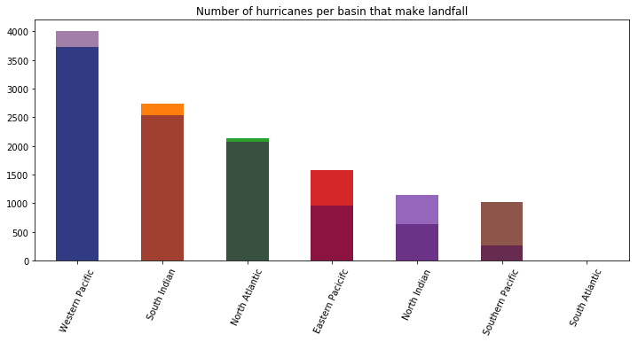

```python
fig1, ax1 = plt.subplots(1,1, figsize=(12,5))

basin_ax = all_hurricanes_df['any_basin'].value_counts().plot(kind='bar', ax=ax1)
basin_ax = landfall_tracks_df['any_basin'].value_counts().plot(kind='bar',
                                                               ax=ax1,
                                                               cmap='viridis',
                                                               alpha=0.5)
basin_ax.set_title('Number of hurricanes per basin that make landfall')
basin_ax.tick_params(axis='x', labelrotation=65)
basin_ax.set_xticklabels(['Western Pacific', 'South Indian', 'North Atlantic',
                          'Eastern Pacicifc', 'North Indian','Southern Pacific',
                          'South Atlantic'])
basin_ax.tick_params()
```

The bar chart above plots the number of hurricanes (per basin) that made landfall over another bar chart of the total number of hurricanes per basin. From the chart, most hurricanes in the **Western Pacific**, **South Indian**, **North Atlantic** make landfall. Hurricanes in **Southern Pacific** on the otherhand rarely make landfall. This helps us guage the severity of hurricanes in different geographic basins.

### How far do hurricanes travel inland after landfall?

Hurricanes in general lose velocity and intensity after they make a landfall. Thus they can only travel a short distance inland. As a result of the overlay analysis, an `analysislength` column is created. We can plot the histogram of that column to understand how far hurricanes have traveled inland after landfall.

```
Text(0.5,0,'Distance in miles')
```

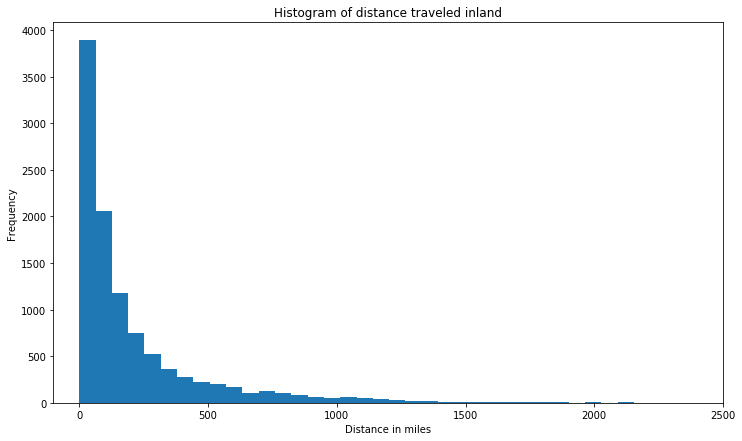

```python
landfall_tracks_df['analysislength'].plot(kind='hist', bins=100,
                                          title='Histogram of distance traveled inland',
                                         figsize=(12,7), xlim=[-100,2500])
plt.xlabel('Distance in miles')
```

Thus, majority of hurricanes travel less than `500` miles after making a landfall. We can query which are the top `50` hurricanes that have traveled longest inland.

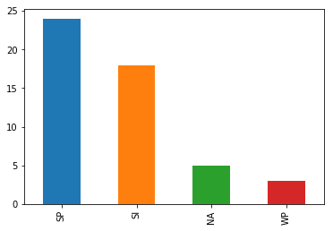

```python
# filter the top 50 longest hurricanes (distance traveled inland)
top_50_longest = landfall_tracks_df.sort_values(by=['analysislength'], axis=0, ascending=False).head(50)
top_50_longest['any_basin'].value_counts().plot(kind='bar')
```

**Southern Pacific** basin, followed by **South Indian** basin contains the hurricanes that have traveled longest inland.

[figure not shown]

```python
inland_map = gis.map()
inland_map
```

```python
top_50_longest.spatial.plot(inland_map, renderer_type='u', col='any_basin',cmap='prism')
```

```
True
```

### Where do hurricanes make landfall?

Of equal interest is finding where hurricanes make landfall. From experience we know certain regions are prone to hurricane damage more than the rest. Using spatial data science, we can empirically derive those regions that have statistically more hurricane landfalls compared to the rest.

For this, we will repeat the **overlay analysis**, however this time, we will change the `output_type` to `POINT`. The tool will return the points along the coast lines where hurricanes make landfall.

```python
%%time
landfall_item = overlay_layers(input_layer=hurricane_fl, overlay_layer = boundary_fl,
                               overlay_type='INTERSECT', output_type='POINT',
                               output_name='hurricane_landfall_locations', gis=gis)
```

```
CPU times: user 1.43 s, sys: 258 ms, total: 1.69 s
Wall time: 24min 41s
```

```python
landfall_points_fl = landfall_item.layers[0]
```

[figure not shown]

```python
landfall_map = gis.map()
landfall_map
```

```python
landfall_map.add_layer(landfall_item)
```

#### Perform density anlaysis on hurricane landfall locations

The map above shows hundreds of thousands of points spread around the world. Do all these places have equal probability of being hit by a hurricane? To answer this, we will perform **density analysis**. The `calculate_density` tool available under the `analyze_patterns` toolset is used for this.

```python
%%time
from arcgis.features.analyze_patterns import calculate_density
landfall_density_item = calculate_density(input_layer=landfall_points_fl, radius=30,
                                          radius_units='Miles', area_units='SquareMiles',
                                          classification_type='NaturalBreaks', num_classes=7,
                                          output_name='landfall_density', gis=gis)
```

```
CPU times: user 80.9 ms, sys: 15.3 ms, total: 96.2 ms
Wall time: 42.7 s
```

[figure not shown]

```python
landfall_map = gis.map('Florida, USA')
landfall_map
```

```python
landfall_map.add_layer(landfall_density_item)
```

The map here computes the kernel density of landfall locations. It does this by summing the number of landfalls within a radius of `30` miles and dividing it by the area of this radius. Thus it spreads the number of landfalls over a smooth surface, then classifies this surface into `7` classes. By performing density anlaysis, we are able to wade through large clouds of landfall points and identify locations that have more landfalls compared to the rest of the world.

Let us visualize the density analysis results on a table and as a chart.

```python
landfall_density_sdf = landfall_density_item.layers[0].query(as_df=True)
landfall_density_sdf.head()
```

|  | SHAPE | analysisarea | class | objectid | value_max_per_squaremile | value_min_per_squaremile |
| --- | --- | --- | --- | --- | --- | --- |
| 0 | {"rings": [[[53.845677534778474, 81.0534260146... | 920.649527 | 2 | 1 | 0.010679 | 0.00267 |
| 1 | {"rings": [[[24.78192557105382, 79.98490572185... | 1896.053559 | 2 | 2 | 0.010679 | 0.00267 |
| 2 | {"rings": [[[15.16524293599764, 79.45064557546... | 162.088581 | 2 | 3 | 0.010679 | 0.00267 |
| 3 | {"rings": [[[12.600794233316094, 65.2393256814... | 183.094538 | 2 | 4 | 0.010679 | 0.00267 |
| 4 | {"rings": [[[-13.79165699844873, 64.5982135057... | 1672.631881 | 2 | 5 | 0.010679 | 0.00267 |

```
Text(0.5,1,'Histogram of hurricane landfall densities')
```

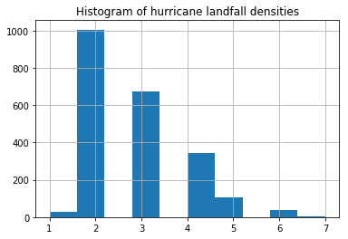

```python
ax = landfall_density_sdf['class'].hist()
ax.set_title('Histogram of hurricane landfall densities')
```

From the histogram above, we notice there are only a very few places that can be classified as having a high density of hurricane landfalls. Let us analyze these places a bit further.

```python
high_density_landfalls = landfall_density_sdf[(landfall_density_sdf['class']==6) |
                                              (landfall_density_sdf['class']==7)]

high_density_landfalls.shape
```

```
(40, 6)
```

We have identified `40` sites worldwide that have a high density of hurricane landfalls based on the anlaysis of data spanning the last `169` years. Below, we plot them on a map.

[figure not shown]

```python
high_density_landfall_map1 = gis.map('North Carolina')
high_density_landfall_map2 = gis.map('China')
display(high_density_landfall_map1)
display(high_density_landfall_map2)
```

```python
high_density_landfalls.spatial.plot(map_widget=high_density_landfall_map1, line_width=0, outline_color=0)
high_density_landfalls.spatial.plot(map_widget=high_density_landfall_map2, line_width=0, outline_color=0)
```

```
True
```

The places that turn up are not much of a surprise. We notice the coast of **Carolinas** in the United States, the states of **West Bengal**, **Orissa** in India, several places along the East coast of **China**, southern tip of **Japan** and most of the island of **Philippines** are the places that are most affected on a repeat basis.

### What is the demographics of places with highest density of landfalls?

Now that we have found the places that have the highest desnity of landfalls, we are faced with the question, who lives there? What is the impact of repeat natural calamities on these places? We can answer those questions by **geoenriching** those polygons with demographic and socio-economic attributes.

> Note: Geoenrichment costs ArcGIS Online credits and requires this functionality to be configured in your Portal for ArcGIS.

Below we use the `enrich()` function to add socio-economic columns to the landfall density `DataFrame`. For a data collection, we pick `keyGlobalFacts` which is available for most part of the world.

```python
landfalls_enriched = enrich(high_density_landfalls, data_collections='keyGlobalFacts')
landfalls_enriched.head()
```

|  | AVGHHSZ | HasData | ID | OBJECTID_0 | SHAPE | TOTFEMALES | TOTHH | TOTMALES | TOTPOP | aggregationMethod | analysisarea | apportionmentConfidence | class | objectid | populationToPolygonSizeRating | sourceCountry | value_max_per_squaremile | value_min_per_squaremile |
| --- | --- | --- | --- | --- | --- | --- | --- | --- | --- | --- | --- | --- | --- | --- | --- | --- | --- | --- |
| 0 | 2.49 | 1 | 0 | 1 | {"rings": [[[-75.76583397992073, 36.0687216884... | 3514 | 2815 | 3500 | 7014 | BlockApportionment:US.BlockGroups | 118.233701 | 2.576 | 7 | 170 | 2.191 | US | 0.226918 | 0.122803 |
| 1 | 2.44 | 1 | 1 | 2 | {"rings": [[[-76.19324209703427, 36.3892777762... | 23548 | 19172 | 23631 | 47179 | BlockApportionment:US.BlockGroups | 1165.144645 | 2.576 | 6 | 174 | 2.191 | US | 0.122803 | 0.067631 |
| 2 | 2.21 | 1 | 2 | 3 | {"rings": [[[-76.40694615559107, 34.8933493663... | 6210 | 5485 | 6521 | 12731 | BlockApportionment:US.BlockGroups | 731.245665 | 2.576 | 6 | 194 | 2.191 | US | 0.122803 | 0.067631 |
| 3 | 2.70 | 1 | 3 | 4 | {"rings": [[[130.2448784688346, 32.54260472224... | 11118 | 7816 | 9969 | 21087 | BlockApportionment:JP.Blocks | 106.236904 | 2.090 | 6 | 275 | 1.695 | JP | 0.122803 | 0.067631 |
| 4 | 2.39 | 1 | 4 | 5 | {"rings": [[[-80.57417529744856, 32.2220486344... | 27843 | 21425 | 28081 | 55924 | BlockApportionment:US.BlockGroups | 255.801403 | 2.576 | 6 | 280 | 2.191 | US | 0.122803 | 0.067631 |

The `enrich()` operation accepts the Spatially Enabled `DataFrame`, performs spatial aggregation and returns another `DataFrame` with socio-economic and demographic columns added to it. The `data_collections` parameter decides which additional columns get added.

Let us visualize the population that is affected by country. For this, we group by the `sourceCountry` column and sum up the results. The cell below plots the total number of men, women and households that live within the high density polygons.

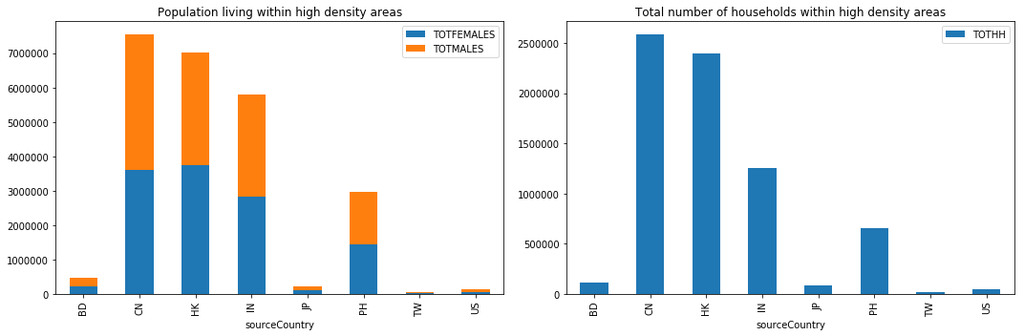

```python
fig, ax = plt.subplots(1,2, figsize=(15,5))
# plot bar chart 1
grouper1 = landfalls_enriched[['TOTFEMALES','TOTMALES','sourceCountry']].groupby(by='sourceCountry')
grouper1.sum().plot(kind='bar', stacked=True, ax=ax[0],
                    title='Population living within high density areas')

# plot bar chart 2
grouper2 = landfalls_enriched[['TOTHH','sourceCountry']].groupby(by='sourceCountry')
grouper2.sum().plot(kind='bar', ax=ax[1],
                    title='Total number of households within high density areas')

plt.tight_layout()
```

Hurricanes make landfalls on coasts, which invariably are places of dense population. By geo enriching the density maps, we are able to determine that the coasts of **China** (7 million), **Hongkong** (7M), **India** (6M) and **Philippines** (3M) are at high risk as they suffer repeat landfalls and also support large populations.

This information can be used by city planners to better zone the coasts and avoid development along hurricane prone areas.

## Conclusion

In this notebook we accessed the aggregated hurricane track data from Part 1 as Spatially Enabled `DataFrame` objects. We visualized these DataFrames both spatially and as charts to reveal interesting information about the global hurricane dataset.

As for hurricane names, the top spot is a tie between **Irma** and **Florence**, with `15` occurrences for each so far. By turning this DataFrame into a timeseries, we were able to observe a sinusoidal seasonality. The peaks between hurricanes in northern and cyclones in southern hemisphere were offest by about `6` months, matching the time when summer occurs in these hemispheres. We also noticed that hurricanes over the **North Indian** basin occur throughout the year as they are influenced by a monsoon phenomena.

We extended the overlay analysis to calculate the exact points where landfall occurs. After performing a density analysis on the landfall locations we found places along the coasts of **Carolinas** in the United States, **Orissa, West Bengal** in India, several places along the east coast of **China**, southern tip of **Japan** and most of **Phillippines** are affected from a repeat landfall / historical perspective.

By geo-enriching the high density places, we were able to understand the number of people that live in these places. **China** tops the list with most people affected.

In the next notebook, we extend this analysis to answer the important question: Does the intensity of hurricanes increase over time?